# Optimal Treatment Analysis

## Outcome Variable

**Outcome Variable:** whz

## Predictor Variables

**Intervention Variable:** impfloor

**Adjustment Set:**

- arm
- sex
- W_mage
- meducyrs
- feducyrs
- hhwealth_quart
- hfoodsec
- W_mhtcm
- W_mwtkg
- W_mbmi
- W_nrooms
- W_nchldlt5
- W_parity
- impsan
- safeh20
- delta_W_mage
- delta_meducyrs
- delta_feducyrs
- delta_hhwealth_quart
- delta_hfoodsec
- delta_W_mhtcm
- delta_W_mwtkg
- delta_W_mbmi
- delta_W_nrooms
- delta_W_nchldlt5
- delta_W_parity
- delta_impsan
- delta_safeh20

## Stratifying Variables

The analysis was stratified on these variable(s):

- agecat
- studyid
- country

## Data Summary

| agecat | studyid | country | impfloor | n_cell | n |
| --- | --- | --- | --- | --- | --- |
| Birth | ki0047075b-MAL-ED | BANGLADESH | 1 | 185 | 201 |
| Birth | ki0047075b-MAL-ED | BANGLADESH | 0 | 16 | 201 |
| Birth | ki0047075b-MAL-ED | BRAZIL | 1 | 55 | 57 |
| Birth | ki0047075b-MAL-ED | BRAZIL | 0 | 2 | 57 |
| Birth | ki0047075b-MAL-ED | INDIA | 1 | 33 | 39 |
| Birth | ki0047075b-MAL-ED | INDIA | 0 | 6 | 39 |
| Birth | ki0047075b-MAL-ED | NEPAL | 1 | 8 | 24 |
| Birth | ki0047075b-MAL-ED | NEPAL | 0 | 16 | 24 |
| Birth | ki0047075b-MAL-ED | PERU | 1 | 37 | 210 |
| Birth | ki0047075b-MAL-ED | PERU | 0 | 173 | 210 |
| Birth | ki0047075b-MAL-ED | SOUTH AFRICA | 1 | 86 | 95 |
| Birth | ki0047075b-MAL-ED | SOUTH AFRICA | 0 | 9 | 95 |
| Birth | ki0047075b-MAL-ED | TANZANIA, UNITED REPUBLIC OF | 1 | 5 | 111 |
| Birth | ki0047075b-MAL-ED | TANZANIA, UNITED REPUBLIC OF | 0 | 106 | 111 |
| Birth | ki1000108-CMC-V-BCS-2002 | INDIA | 1 | 68 | 68 |
| Birth | ki1000108-CMC-V-BCS-2002 | INDIA | 0 | 0 | 68 |
| Birth | ki1000108-IRC | INDIA | 1 | 253 | 253 |
| Birth | ki1000108-IRC | INDIA | 0 | 0 | 253 |
| Birth | ki1017093-NIH-Birth | BANGLADESH | 1 | 505 | 572 |
| Birth | ki1017093-NIH-Birth | BANGLADESH | 0 | 67 | 572 |
| Birth | ki1017093b-PROVIDE | BANGLADESH | 1 | 485 | 532 |
| Birth | ki1017093b-PROVIDE | BANGLADESH | 0 | 47 | 532 |
| Birth | ki1017093c-NIH-Crypto | BANGLADESH | 1 | 542 | 707 |
| Birth | ki1017093c-NIH-Crypto | BANGLADESH | 0 | 165 | 707 |
| Birth | ki1113344-GMS-Nepal | NEPAL | 1 | 97 | 503 |
| Birth | ki1113344-GMS-Nepal | NEPAL | 0 | 406 | 503 |
| Birth | ki1114097-CONTENT | PERU | 1 | 2 | 2 |
| Birth | ki1114097-CONTENT | PERU | 0 | 0 | 2 |
| Birth | kiGH5241-JiVitA-3 | BANGLADESH | 1 | 1215 | 17966 |
| Birth | kiGH5241-JiVitA-3 | BANGLADESH | 0 | 16751 | 17966 |

[output cut: 66 more lines]

The following strata were considered:

- agecat: 24 months, studyid: ki0047075b-MAL-ED, country: BANGLADESH
- agecat: 24 months, studyid: ki0047075b-MAL-ED, country: BRAZIL
- agecat: 24 months, studyid: ki0047075b-MAL-ED, country: INDIA
- agecat: 24 months, studyid: ki0047075b-MAL-ED, country: NEPAL
- agecat: 24 months, studyid: ki0047075b-MAL-ED, country: PERU
- agecat: 24 months, studyid: ki0047075b-MAL-ED, country: SOUTH AFRICA
- agecat: 24 months, studyid: ki0047075b-MAL-ED, country: TANZANIA, UNITED REPUBLIC OF
- agecat: 24 months, studyid: ki1000108-CMC-V-BCS-2002, country: INDIA
- agecat: 24 months, studyid: ki1000108-IRC, country: INDIA
- agecat: 24 months, studyid: ki1017093-NIH-Birth, country: BANGLADESH
- agecat: 24 months, studyid: ki1017093b-PROVIDE, country: BANGLADESH
- agecat: 24 months, studyid: ki1017093c-NIH-Crypto, country: BANGLADESH
- agecat: 24 months, studyid: ki1113344-GMS-Nepal, country: NEPAL
- agecat: 24 months, studyid: ki1114097-CONTENT, country: PERU
- agecat: 24 months, studyid: kiGH5241-JiVitA-3, country: BANGLADESH
- agecat: 24 months, studyid: kiGH5241-JiVitA-4, country: BANGLADESH
- agecat: 6 months, studyid: ki0047075b-MAL-ED, country: BANGLADESH
- agecat: 6 months, studyid: ki0047075b-MAL-ED, country: BRAZIL
- agecat: 6 months, studyid: ki0047075b-MAL-ED, country: INDIA
- agecat: 6 months, studyid: ki0047075b-MAL-ED, country: NEPAL
- agecat: 6 months, studyid: ki0047075b-MAL-ED, country: PERU
- agecat: 6 months, studyid: ki0047075b-MAL-ED, country: SOUTH AFRICA
- agecat: 6 months, studyid: ki0047075b-MAL-ED, country: TANZANIA, UNITED REPUBLIC OF
- agecat: 6 months, studyid: ki1000108-CMC-V-BCS-2002, country: INDIA
- agecat: 6 months, studyid: ki1000108-IRC, country: INDIA
- agecat: 6 months, studyid: ki1017093-NIH-Birth, country: BANGLADESH
- agecat: 6 months, studyid: ki1017093b-PROVIDE, country: BANGLADESH
- agecat: 6 months, studyid: ki1017093c-NIH-Crypto, country: BANGLADESH
- agecat: 6 months, studyid: ki1113344-GMS-Nepal, country: NEPAL
- agecat: 6 months, studyid: ki1114097-CONTENT, country: PERU
- agecat: 6 months, studyid: kiGH5241-JiVitA-3, country: BANGLADESH
- agecat: 6 months, studyid: kiGH5241-JiVitA-4, country: BANGLADESH
- agecat: Birth, studyid: ki0047075b-MAL-ED, country: BANGLADESH
- agecat: Birth, studyid: ki0047075b-MAL-ED, country: BRAZIL
- agecat: Birth, studyid: ki0047075b-MAL-ED, country: INDIA
- agecat: Birth, studyid: ki0047075b-MAL-ED, country: NEPAL
- agecat: Birth, studyid: ki0047075b-MAL-ED, country: PERU
- agecat: Birth, studyid: ki0047075b-MAL-ED, country: SOUTH AFRICA
- agecat: Birth, studyid: ki0047075b-MAL-ED, country: TANZANIA, UNITED REPUBLIC OF
- agecat: Birth, studyid: ki1000108-CMC-V-BCS-2002, country: INDIA
- agecat: Birth, studyid: ki1000108-IRC, country: INDIA
- agecat: Birth, studyid: ki1017093-NIH-Birth, country: BANGLADESH
- agecat: Birth, studyid: ki1017093b-PROVIDE, country: BANGLADESH
- agecat: Birth, studyid: ki1017093c-NIH-Crypto, country: BANGLADESH
- agecat: Birth, studyid: ki1113344-GMS-Nepal, country: NEPAL
- agecat: Birth, studyid: ki1114097-CONTENT, country: PERU
- agecat: Birth, studyid: kiGH5241-JiVitA-3, country: BANGLADESH
- agecat: Birth, studyid: kiGH5241-JiVitA-4, country: BANGLADESH

### Dropped Strata

Some strata were dropped due to rare outcomes:

- agecat: Birth, studyid: ki0047075b-MAL-ED, country: BRAZIL
- agecat: Birth, studyid: ki1000108-CMC-V-BCS-2002, country: INDIA
- agecat: Birth, studyid: ki1000108-IRC, country: INDIA
- agecat: Birth, studyid: ki1114097-CONTENT, country: PERU
- agecat: 6 months, studyid: ki0047075b-MAL-ED, country: BRAZIL
- agecat: 6 months, studyid: ki1000108-CMC-V-BCS-2002, country: INDIA
- agecat: 6 months, studyid: ki1000108-IRC, country: INDIA
- agecat: 24 months, studyid: ki0047075b-MAL-ED, country: BRAZIL
- agecat: 24 months, studyid: ki1000108-CMC-V-BCS-2002, country: INDIA
- agecat: 24 months, studyid: ki1000108-IRC, country: INDIA

## Methods Detail

We’re interested in the causal parameters $E[Y_a]$ for all values of $a \in \mathcal{A}$. These parameters represent the mean outcome if, possibly contrary to fact, we intervened to set all units to have $A=a$. Under the randomization and positivity assumptions, these are identified by the statistical parameters $\psi_a=E_W[E_{Y|A,W}(Y|A=a,W)]$. In addition, we’re interested in the mean of $Y$, $E[Y]$ under no intervention (the observed mean). We will estimate these parameters by using SuperLearner to fit the relevant likelihood factors – $E_{Y|A,W}(Y|A=a,W)$ and $p(A=a|W)$, and then updating our likelihood fit using a joint TMLE.

For unadjusted analyses ($W=\{\}$), initial likelihoods were estimated using Lrnr_glm to estimate the simple $E(Y|A)$ and Lrnr_mean to estimate $p(A)$. For adjusted analyses, a small library containing Lrnr_glmnet, Lrnr_xgboost, and Lrnr_mean was used.

Having estimated these parameters, we will then use the delta method to estimate relative risks and attributable risks relative to a prespecified baseline level of $A$.

# Results Detail

## Results Plots

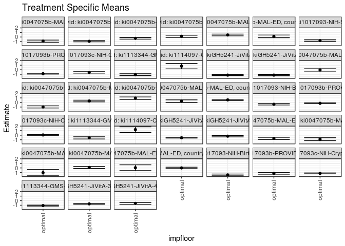

## Results Table

### Parameter: TSM

| agecat | studyid | country | intervention_level | baseline_level | estimate | ci_lower | ci_upper |
| --- | --- | --- | --- | --- | --- | --- | --- |
| Birth | ki0047075b-MAL-ED | BANGLADESH | optimal | observed | -0.6994600 | -0.9367445 | -0.4621755 |
| Birth | ki0047075b-MAL-ED | INDIA | optimal | observed | -0.8788761 | -1.1985323 | -0.5592200 |
| Birth | ki0047075b-MAL-ED | NEPAL | optimal | observed | -1.0391778 | -1.7251563 | -0.3531992 |
| Birth | ki0047075b-MAL-ED | PERU | optimal | observed | 0.1000627 | -0.1170403 | 0.3171658 |
| Birth | ki0047075b-MAL-ED | SOUTH AFRICA | optimal | observed | 0.0451108 | -0.5952335 | 0.6854550 |
| Birth | ki0047075b-MAL-ED | TANZANIA, UNITED REPUBLIC OF | optimal | observed | 0.0014424 | -0.1610541 | 0.1639388 |
| Birth | ki1017093-NIH-Birth | BANGLADESH | optimal | observed | -1.5326631 | -1.7275189 | -1.3378074 |
| Birth | ki1017093b-PROVIDE | BANGLADESH | optimal | observed | -1.2003187 | -1.3775499 | -1.0230875 |
| Birth | ki1017093c-NIH-Crypto | BANGLADESH | optimal | observed | -1.1962520 | -1.2894398 | -1.1030642 |
| Birth | ki1113344-GMS-Nepal | NEPAL | optimal | observed | -1.0825661 | -1.1905845 | -0.9745477 |
| Birth | kiGH5241-JiVitA-3 | BANGLADESH | optimal | observed | -0.7061026 | -0.7797137 | -0.6324914 |
| Birth | kiGH5241-JiVitA-4 | BANGLADESH | optimal | observed | -0.5961385 | -0.7918590 | -0.4004181 |
| 6 months | ki0047075b-MAL-ED | BANGLADESH | optimal | observed | -0.0437751 | -0.3046517 | 0.2171016 |
| 6 months | ki0047075b-MAL-ED | INDIA | optimal | observed | -0.9728922 | -1.2109163 | -0.7348681 |
| 6 months | ki0047075b-MAL-ED | NEPAL | optimal | observed | 0.3180415 | 0.1321885 | 0.5038945 |
| 6 months | ki0047075b-MAL-ED | PERU | optimal | observed | 0.9426438 | 0.6727578 | 1.2125298 |
| 6 months | ki0047075b-MAL-ED | SOUTH AFRICA | optimal | observed | 0.2911667 | 0.0095125 | 0.5728210 |
| 6 months | ki0047075b-MAL-ED | TANZANIA, UNITED REPUBLIC OF | optimal | observed | 0.5669584 | 0.4310240 | 0.7028928 |
| 6 months | ki1017093-NIH-Birth | BANGLADESH | optimal | observed | -0.3983647 | -0.5498305 | -0.2468988 |
| 6 months | ki1017093b-PROVIDE | BANGLADESH | optimal | observed | -0.1778108 | -0.2643954 | -0.0912262 |
| 6 months | ki1017093c-NIH-Crypto | BANGLADESH | optimal | observed | 0.0510124 | -0.0398506 | 0.1418754 |
| 6 months | ki1113344-GMS-Nepal | NEPAL | optimal | observed | -0.5866556 | -0.8271282 | -0.3461831 |
| 6 months | ki1114097-CONTENT | PERU | optimal | observed | 1.2282124 | 0.6160569 | 1.8403680 |
| 6 months | kiGH5241-JiVitA-3 | BANGLADESH | optimal | observed | -0.5573857 | -0.6318363 | -0.4829352 |
| 6 months | kiGH5241-JiVitA-4 | BANGLADESH | optimal | observed | -0.2151918 | -0.3629663 | -0.0674173 |
| 24 months | ki0047075b-MAL-ED | BANGLADESH | optimal | observed | -0.9116241 | -1.1463979 | -0.6768503 |
| 24 months | ki0047075b-MAL-ED | INDIA | optimal | observed | -0.9341961 | -1.0556385 | -0.8127537 |
| 24 months | ki0047075b-MAL-ED | NEPAL | optimal | observed | -0.2893870 | -0.4607100 | -0.1180640 |
| 24 months | ki0047075b-MAL-ED | PERU | optimal | observed | 0.1591475 | -0.0830341 | 0.4013291 |
| 24 months | ki0047075b-MAL-ED | SOUTH AFRICA | optimal | observed | 0.4490946 | 0.2533131 | 0.6448762 |
| 24 months | ki0047075b-MAL-ED | TANZANIA, UNITED REPUBLIC OF | optimal | observed | 0.1377650 | -0.1584310 | 0.4339609 |
| 24 months | ki1017093-NIH-Birth | BANGLADESH | optimal | observed | -0.7798729 | -0.9426385 | -0.6171073 |
| 24 months | ki1017093b-PROVIDE | BANGLADESH | optimal | observed | -0.8687510 | -0.9545750 | -0.7829271 |
| 24 months | ki1017093c-NIH-Crypto | BANGLADESH | optimal | observed | -0.5860697 | -0.7453405 | -0.4267990 |
| 24 months | ki1113344-GMS-Nepal | NEPAL | optimal | observed | -1.0816399 | -1.2863820 | -0.8768978 |
| 24 months | ki1114097-CONTENT | PERU | optimal | observed | 0.7940625 | 0.1966429 | 1.3914821 |
| 24 months | kiGH5241-JiVitA-3 | BANGLADESH | optimal | observed | -1.1768309 | -1.2814940 | -1.0721679 |
| 24 months | kiGH5241-JiVitA-4 | BANGLADESH | optimal | observed | -1.1777084 | -1.3108145 | -1.0446022 |

### Parameter: E(Y)

| agecat | studyid | country | intervention_level | baseline_level | estimate | ci_lower | ci_upper |
| --- | --- | --- | --- | --- | --- | --- | --- |
| Birth | ki0047075b-MAL-ED | BANGLADESH | observed | observed | -0.9728358 | -1.1217009 | -0.8239707 |
| Birth | ki0047075b-MAL-ED | INDIA | observed | observed | -0.9441026 | -1.2397919 | -0.6484132 |
| Birth | ki0047075b-MAL-ED | NEPAL | observed | observed | -0.8087500 | -1.1914221 | -0.4260779 |
| Birth | ki0047075b-MAL-ED | PERU | observed | observed | -0.0468095 | -0.1738806 | 0.0802616 |
| Birth | ki0047075b-MAL-ED | SOUTH AFRICA | observed | observed | -0.1729474 | -0.4186222 | 0.0727275 |
| Birth | ki0047075b-MAL-ED | TANZANIA, UNITED REPUBLIC OF | observed | observed | 0.7690991 | 0.5714748 | 0.9667234 |
| Birth | ki1017093-NIH-Birth | BANGLADESH | observed | observed | -1.3448514 | -1.4396716 | -1.2500312 |
| Birth | ki1017093b-PROVIDE | BANGLADESH | observed | observed | -1.2984586 | -1.3752758 | -1.2216415 |
| Birth | ki1017093c-NIH-Crypto | BANGLADESH | observed | observed | -1.2441513 | -1.3281130 | -1.1601897 |
| Birth | ki1113344-GMS-Nepal | NEPAL | observed | observed | -1.0860636 | -1.1830454 | -0.9890818 |
| Birth | kiGH5241-JiVitA-3 | BANGLADESH | observed | observed | -0.7773511 | -0.7963777 | -0.7583245 |
| Birth | kiGH5241-JiVitA-4 | BANGLADESH | observed | observed | -0.6882498 | -0.7406539 | -0.6358456 |
| 6 months | ki0047075b-MAL-ED | BANGLADESH | observed | observed | -0.1333333 | -0.2623761 | -0.0042906 |
| 6 months | ki0047075b-MAL-ED | INDIA | observed | observed | -0.7102872 | -0.8371659 | -0.5834085 |
| 6 months | ki0047075b-MAL-ED | NEPAL | observed | observed | 0.1281441 | -0.0056126 | 0.2619008 |
| 6 months | ki0047075b-MAL-ED | PERU | observed | observed | 1.0512099 | 0.9285617 | 1.1738581 |
| 6 months | ki0047075b-MAL-ED | SOUTH AFRICA | observed | observed | 0.5404351 | 0.3867005 | 0.6941696 |
| 6 months | ki0047075b-MAL-ED | TANZANIA, UNITED REPUBLIC OF | observed | observed | 0.5355782 | 0.4032519 | 0.6679046 |
| 6 months | ki1017093-NIH-Birth | BANGLADESH | observed | observed | -0.4447399 | -0.5354039 | -0.3540758 |
| 6 months | ki1017093b-PROVIDE | BANGLADESH | observed | observed | -0.1990907 | -0.2817968 | -0.1163845 |
| 6 months | ki1017093c-NIH-Crypto | BANGLADESH | observed | observed | 0.0297622 | -0.0491685 | 0.1086930 |
| 6 months | ki1113344-GMS-Nepal | NEPAL | observed | observed | -0.6273772 | -0.7253868 | -0.5293676 |
| 6 months | ki1114097-CONTENT | PERU | observed | observed | 1.0684318 | 0.9515274 | 1.1853362 |
| 6 months | kiGH5241-JiVitA-3 | BANGLADESH | observed | observed | -0.5926720 | -0.6122891 | -0.5730549 |
| 6 months | kiGH5241-JiVitA-4 | BANGLADESH | observed | observed | -0.3901347 | -0.4273932 | -0.3528762 |
| 24 months | ki0047075b-MAL-ED | BANGLADESH | observed | observed | -0.8192925 | -0.9412667 | -0.6973182 |
| 24 months | ki0047075b-MAL-ED | INDIA | observed | observed | -0.9516520 | -1.0670654 | -0.8362385 |
| 24 months | ki0047075b-MAL-ED | NEPAL | observed | observed | -0.3471493 | -0.4618867 | -0.2324120 |
| 24 months | ki0047075b-MAL-ED | PERU | observed | observed | 0.1111982 | -0.0118399 | 0.2342362 |
| 24 months | ki0047075b-MAL-ED | SOUTH AFRICA | observed | observed | 0.4090301 | 0.2879441 | 0.5301161 |
| 24 months | ki0047075b-MAL-ED | TANZANIA, UNITED REPUBLIC OF | observed | observed | 0.0477437 | -0.0779935 | 0.1734809 |
| 24 months | ki1017093-NIH-Birth | BANGLADESH | observed | observed | -0.9106710 | -1.0090143 | -0.8123277 |
| 24 months | ki1017093b-PROVIDE | BANGLADESH | observed | observed | -0.8928670 | -0.9755153 | -0.8102187 |
| 24 months | ki1017093c-NIH-Crypto | BANGLADESH | observed | observed | -0.6103502 | -0.7050157 | -0.5156847 |
| 24 months | ki1113344-GMS-Nepal | NEPAL | observed | observed | -1.1990840 | -1.3039914 | -1.0941766 |
| 24 months | ki1114097-CONTENT | PERU | observed | observed | 0.5668293 | 0.4302437 | 0.7034148 |
| 24 months | kiGH5241-JiVitA-3 | BANGLADESH | observed | observed | -1.2970420 | -1.3203145 | -1.2737694 |
| 24 months | kiGH5241-JiVitA-4 | BANGLADESH | observed | observed | -1.2232311 | -1.2550891 | -1.1913732 |

### Parameter: PAR

| agecat | studyid | country | intervention_level | baseline_level | estimate | ci_lower | ci_upper |
| --- | --- | --- | --- | --- | --- | --- | --- |
| Birth | ki0047075b-MAL-ED | BANGLADESH | optimal | observed | -0.2733758 | -0.5366080 | -0.0101436 |
| Birth | ki0047075b-MAL-ED | INDIA | optimal | observed | -0.0652264 | -0.2001667 | 0.0697139 |
| Birth | ki0047075b-MAL-ED | NEPAL | optimal | observed | 0.2304278 | -0.2466362 | 0.7074917 |
| Birth | ki0047075b-MAL-ED | PERU | optimal | observed | -0.1468723 | -0.3274976 | 0.0337531 |
| Birth | ki0047075b-MAL-ED | SOUTH AFRICA | optimal | observed | -0.2180581 | -0.8593470 | 0.4232307 |
| Birth | ki0047075b-MAL-ED | TANZANIA, UNITED REPUBLIC OF | optimal | observed | 0.7676567 | 0.5807566 | 0.9545569 |
| Birth | ki1017093-NIH-Birth | BANGLADESH | optimal | observed | 0.1878117 | 0.0069426 | 0.3686809 |
| Birth | ki1017093b-PROVIDE | BANGLADESH | optimal | observed | -0.0981400 | -0.2657534 | 0.0694735 |
| Birth | ki1017093c-NIH-Crypto | BANGLADESH | optimal | observed | -0.0478993 | -0.0953241 | -0.0004746 |
| Birth | ki1113344-GMS-Nepal | NEPAL | optimal | observed | -0.0034975 | -0.0515035 | 0.0445085 |
| Birth | kiGH5241-JiVitA-3 | BANGLADESH | optimal | observed | -0.0712485 | -0.1409848 | -0.0015123 |
| Birth | kiGH5241-JiVitA-4 | BANGLADESH | optimal | observed | -0.0921112 | -0.2798283 | 0.0956058 |
| 6 months | ki0047075b-MAL-ED | BANGLADESH | optimal | observed | -0.0895583 | -0.3133453 | 0.1342288 |
| 6 months | ki0047075b-MAL-ED | INDIA | optimal | observed | 0.2626049 | 0.0253683 | 0.4998415 |
| 6 months | ki0047075b-MAL-ED | NEPAL | optimal | observed | -0.1898974 | -0.3356735 | -0.0441213 |
| 6 months | ki0047075b-MAL-ED | PERU | optimal | observed | 0.1085661 | -0.1258742 | 0.3430064 |
| 6 months | ki0047075b-MAL-ED | SOUTH AFRICA | optimal | observed | 0.2492683 | -0.0107797 | 0.5093164 |
| 6 months | ki0047075b-MAL-ED | TANZANIA, UNITED REPUBLIC OF | optimal | observed | -0.0313801 | -0.0719353 | 0.0091750 |
| 6 months | ki1017093-NIH-Birth | BANGLADESH | optimal | observed | -0.0463752 | -0.1671891 | 0.0744387 |
| 6 months | ki1017093b-PROVIDE | BANGLADESH | optimal | observed | -0.0212798 | -0.0439487 | 0.0013891 |
| 6 months | ki1017093c-NIH-Crypto | BANGLADESH | optimal | observed | -0.0212501 | -0.0679338 | 0.0254335 |
| 6 months | ki1113344-GMS-Nepal | NEPAL | optimal | observed | -0.0407215 | -0.2590424 | 0.1775993 |
| 6 months | ki1114097-CONTENT | PERU | optimal | observed | -0.1597807 | -0.7504707 | 0.4309094 |
| 6 months | kiGH5241-JiVitA-3 | BANGLADESH | optimal | observed | -0.0352863 | -0.1079063 | 0.0373338 |
| 6 months | kiGH5241-JiVitA-4 | BANGLADESH | optimal | observed | -0.1749429 | -0.3183115 | -0.0315742 |
| 24 months | ki0047075b-MAL-ED | BANGLADESH | optimal | observed | 0.0923316 | -0.1008203 | 0.2854836 |
| 24 months | ki0047075b-MAL-ED | INDIA | optimal | observed | -0.0174559 | -0.0490973 | 0.0141855 |
| 24 months | ki0047075b-MAL-ED | NEPAL | optimal | observed | -0.0577623 | -0.1885495 | 0.0730249 |
| 24 months | ki0047075b-MAL-ED | PERU | optimal | observed | -0.0479493 | -0.2398587 | 0.1439600 |
| 24 months | ki0047075b-MAL-ED | SOUTH AFRICA | optimal | observed | -0.0400645 | -0.2362341 | 0.1561051 |
| 24 months | ki0047075b-MAL-ED | TANZANIA, UNITED REPUBLIC OF | optimal | observed | -0.0900213 | -0.3622294 | 0.1821869 |
| 24 months | ki1017093-NIH-Birth | BANGLADESH | optimal | observed | -0.1307981 | -0.2708946 | 0.0092984 |
| 24 months | ki1017093b-PROVIDE | BANGLADESH | optimal | observed | -0.0241160 | -0.0492217 | 0.0009897 |
| 24 months | ki1017093c-NIH-Crypto | BANGLADESH | optimal | observed | -0.0242805 | -0.1580753 | 0.1095144 |
| 24 months | ki1113344-GMS-Nepal | NEPAL | optimal | observed | -0.1174441 | -0.2930365 | 0.0581482 |
| 24 months | ki1114097-CONTENT | PERU | optimal | observed | -0.2272332 | -0.8121451 | 0.3576786 |
| 24 months | kiGH5241-JiVitA-3 | BANGLADESH | optimal | observed | -0.1202110 | -0.2211908 | -0.0192313 |
| 24 months | kiGH5241-JiVitA-4 | BANGLADESH | optimal | observed | -0.0455228 | -0.1742069 | 0.0831613 |